# Assignment_1_data_607

Jeff Shamp

1/28/2020

# Tracking Congress in the Age of Trump

## Introduction

538.com updates a daily tally of who in congress supports Pres. Trump by voting in alingment with his agend. The also have built a prediction as to how frequently the Congressperson ‘should’ vote in alignment with Pres. Trump based on how that congressperson’s district of state voted in the last general election. They also provide a simple difference between how there actual record differs from the predicted record.

I like this idea becuase it takes the general voting trend of a given district or state as a proxy for hwo aligned that location is with Pres. Trump’s agend. It makes for an interesting view into how well a member of Congress aligns with the voting record of their constituency vs. their alignment with Trump.

For my analysis, I will be focusing on the Senate as they are in the spotlight right for the impeachment trial. I also think the Senate if significantly more out-of-touch with American than the House of Representatives.

First we bring in the data and clean and process some values and columns

```r
library(RCurl)
d<-getURL("https://raw.githubusercontent.com/Shampjeff/cuny_msds/master/DATA_607/data/averages.csv")
d<-read.csv(text=d)
df<-data.frame(d)
senate_df<-subset(df, chamber=='senate')
senate_df$party[senate_df$party == "I"]<- "Independent"
senate_df$party[senate_df$party == "D"]<- "Democrat"
senate_df$party[senate_df$party == "R"]<-"Republican"
head(senate_df)
```

```
##      congress chamber bioguide last_name state district      party votes
## 1418        0  senate  A000360 Alexander    TN       NA Republican   107
## 1419      115  senate  A000360 Alexander    TN       NA Republican    80
## 1420      116  senate  A000360 Alexander    TN       NA Republican    27
## 1421        0  senate  B000575     Blunt    MO       NA Republican   114
## 1422      115  senate  B000575     Blunt    MO       NA Republican    84
## 1423      116  senate  B000575     Blunt    MO       NA Republican    30
##      agree_pct predicted_agree net_trump_vote
## 1418 0.9065421       0.8663454       26.00570
## 1419 0.9375000       0.8795920       26.00570
## 1420 0.8148148       0.8270962       26.00570
## 1421 0.9298246       0.8061049       18.63712
## 1422 0.9642857       0.8299707       18.63712
## 1423 0.8333333       0.7392806       18.63712
```

I’ll also remove some of the columns that I do not think are important for this assignment.

```r
senate_df<- subset(senate_df, select=-c(district,bioguide, chamber))
head(senate_df)
```

```
##      congress last_name state      party votes agree_pct predicted_agree
## 1418        0 Alexander    TN Republican   107 0.9065421       0.8663454
## 1419      115 Alexander    TN Republican    80 0.9375000       0.8795920
## 1420      116 Alexander    TN Republican    27 0.8148148       0.8270962
## 1421        0     Blunt    MO Republican   114 0.9298246       0.8061049
## 1422      115     Blunt    MO Republican    84 0.9642857       0.8299707
## 1423      116     Blunt    MO Republican    30 0.8333333       0.7392806
##      net_trump_vote
## 1418       26.00570
## 1419       26.00570
## 1420       26.00570
## 1421       18.63712
## 1422       18.63712
## 1423       18.63712
```

Now we have all the Senators, their party affliation, and voting stats relative to their constituency.

The last thing that will be removed is the Congresspersons session-by-session record. I’ll simply focus on the Senators aggregated voting record for the time that Trump has been in office. There is a column title `congress` which lets the reader know during which session of Congress the votes were cast. I’ll drop those rows and keep the combined record.

```r
senate_df<- subset(senate_df, congress==0)
senate_df<- subset(senate_df, select=-c(congress))
head(senate_df)
```

```
##      last_name state      party votes agree_pct predicted_agree net_trump_vote
## 1418 Alexander    TN Republican   107 0.9065421       0.8663454     26.0057009
## 1421     Blunt    MO Republican   114 0.9298246       0.8061049     18.6371170
## 1424     Brown    OH   Democrat   114 0.2631579       0.6580150      8.1295744
## 1427      Burr    NC Republican   109 0.9174312       0.5725085      3.6552285
## 1430   Baldwin    WI   Democrat   114 0.2280702       0.5218532      0.7643432
## 1433   Boozman    AR Republican   115 0.9391304       0.8717218     26.9209780
```

## Exploratory Data Analysis

Now that we have cleaned and consistently formatted data, we can explore some basic questions.

### Who votes for Trump when they do not have to?

Within this dataset is a column `net_trump_vote` which is the percent of the this consitutency that voted for Trump minus the percent population that voted for Hillary Clinton. Negative values represent states that voted majority for Clinton, and positive values are populations that majority voted for Trump. As such, it stands to reason that low values, especially low negative values, represent populations that are swing states for Trump. I would not expect a Senator to vote very strongly pro-Trump is this regard, as they seem to be vunerable in elections.

I’ll look for Senators with 3% plus or minus `net_trump_vote` score that also have more than 60% vote alignment with the president.

```r
swing_df<- subset(senate_df, agree_pct>.60 & net_trump_vote>-3 & net_trump_vote<=3)
swing_df
```

```
##      last_name state      party votes agree_pct predicted_agree net_trump_vote
## 1466   Collins    ME Republican   115 0.6695652       0.4495732     -2.9604494
## 1538    Heller    NV Republican    83 0.9156627       0.4997653     -2.4171284
## 1568   Johnson    WI Republican   115 0.8956522       0.5207132      0.7643432
## 1655     Rubio    FL Republican   112 0.9017857       0.5302854      1.1986256
## 1701     Scott    FL Republican    31 0.9032258       0.4294011      1.1986256
## 1706    Toomey    PA Republican   110 0.8727273       0.5160771      0.7242696
```

Indeed there is a very small number of Senators who vote well-aligned with Trump even though their home states are true swing states.

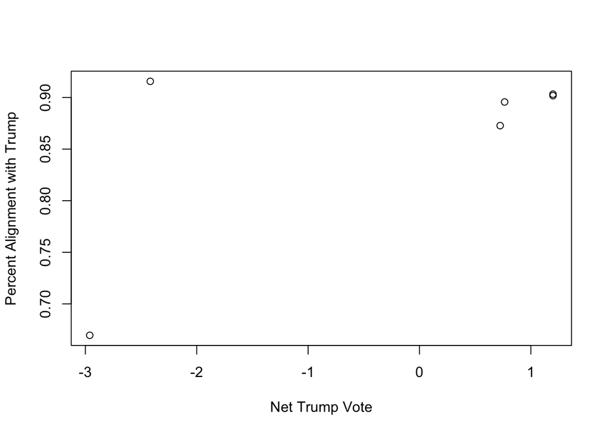

```r
plot(x=swing_df$net_trump_vote, y=swing_df$agree_pct, xlab='Net Trump Vote', ylab = 'Percent Alignment with Trump')
```

If we look at each Senators predicted agreement with Trump vs. their actual agreement with Trump we see that the predicted values are not great overall. Perfect agreement would be a linear relationship.

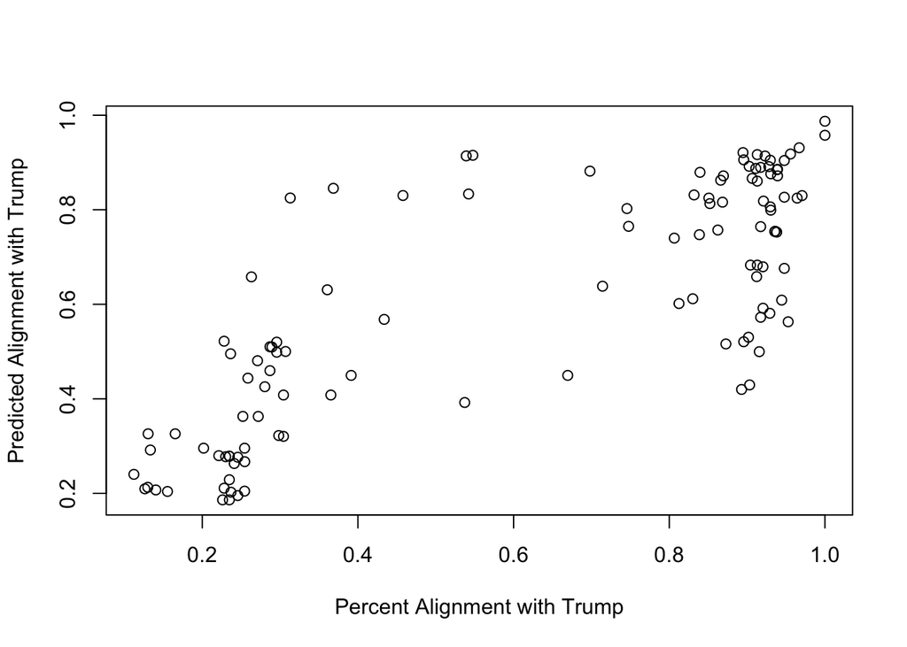

```r
plot(senate_df$predicted_agree~senate_df$agree_pct, xlab='Percent Alignment with Trump',ylab = 'Predicted Alignment with Trump')
```

## Conclusions

If I were a Democratic strategist, I would segment this information further to help identify place to focus time and money to turn out Democratic voters.

In terms of the predicted alignment with Trump, it needs more work. I would like to see primary voting data for swing state Senators like Rick Scott or Susan Collins as their alignment with Trump might be due to the sensibilities of Republican primary voters.